# Wprowadzenie do programowania w R

Podstawy programowania w R

06 październik, 2018

**Mateusz Rzeszutek**

**AGH** Akademia Górniczo-Hutnicza im. Stanisława Staszica w Krakowie, Wydział Geodezji Górniczej i Inżynierii Środowiska, Katedra Kształtowania i Ochrony Środowiska.

**e-mail:** *rzeszut@agh.edu.pl*.

**lokalizacja:** bud. C-4, p. V, pok. 511, al. A. Mickiewicza 30, Kraków, Polska.

**konsultacje:** Zgodnie z informacjami na stronie [dziekanatu](https://dziekanat.geod.agh.edu.pl/dziekanat/index.php?menu1=4&menu2=17&co=o&lin=o&wiad=@f_konsult_prez) lub po uzgodnieniu za pośrednictwem e-mail.

[figure not shown]

# 4. Wczytywanie danych

```r
library(PogromcyDanych)
load(file = "dane.RData")
```

# 7. Typ czynnikowy - cechy jakościowe

**Typ czynnikowy (nazywany również wyliczeniowym lub kategorycznym)**. Ten typ jest przydatny do przechowywania wektorów wartości występujących na kilku poziomach (w kilku kategoriach). Przykładowo płeć występuje na dwóch poziomach, tzn. może przyjmować tylko dwie wartości, dlatego przechowując w programie R wektor danych opisujących płeć, najlepiej użyć typu czynnikowego. Zmienne tego typu są najczęściej wykorzystywane do definiowania grup. Na poniższym przykładzie konstruujemy czteroelementowy wektor elementów typu wyliczeniowego, ze słownikiem składającym się z dwóch wartości (Biecek 2008).

```r
nz <- factor(c("sierzant", "kapitan",
               "sierzant", "sierzant"))
nz
```

```
## [1] sierzant kapitan  sierzant sierzant
## Levels: kapitan sierzant
```

Zmienna nz jest obiektem czynnikowym składającym się z 4 elemetów tekstowych utworzonych z dwóch słów. Każde słowo reprezentuje kategorię.

Przejrzyjmy sie danym typu `factor`:

```r
summary(nz)
table(nz)
str(dane)
```

## 7.1. Wprowadzenie

Za pomocą cech jakościowych opisujemy przynależność danego zbioru danych do pewnej grup. Często cechę tą nazywa się grupową, a w R cechę jakościową oznacza obiekt typu `factor()` czynniki (cecha czynnikowa). Przykładami zmiennych jakościowych są: np. Wykształcenie (podstawowe, średnie, wyższe, specjalistyczne), kraj zamieszkania(PL, GER, RUS ….).

Czasami zmienną jakościowa opisujemy liczbami jest to np. nr albumu, nr telefonu, pesel, kod pocztowy. Zmienną jakosciową, może być np.: Ocena końcowa z TI, ale można ją też traktować jako zmienną ilościową. Tutaj mamy do czynienia z dualnością i jak będzie ta zmienna interpretowana zależny od celu naszych analiz.

Dane jakościowe, lub grupowanie danych jest bardzo ważne ponieważ stanowi podstawę do utworzenia baz danych, oraz pozyskania z baz danych odpowiednich informacji.

Jakkolwiek zmienne jakościowe mogą bardzo różnić się liczbą grup oraz rodzajem grup, można na nich wykonywać kilka wspólnych operacji. omówimy jej w tym rozdziale. Najpierw jednak proszę wczytać zestawy danych `dane` oraz z pakietu `PogromcyDanych` zestaw `auta2012`.

## 7.2. Cechy jakosciowe

Wczytaj zestaw danych `dane` z pliku `"dane.RData"`.

```r
getwd() # gdzie jestem
```

```
## [1] "Z:/R/Kurs_R"
```

```r
# setwd("tam gdzie plik dane.RData") # ustaw lokalizację
load(file = "dane.RData")
```

W celu pewnego uproszczenie skleimy imie i nazwisko w jedną kolumnę (patrz przetwarzanie danych tekstowych)

```r
osoba <- paste(dane$imie,
               dane$nazwisko)
osoba # nowa cecha
```

```
## [1] "Katarzyna Kowalska" "Zofia Kowalska"     "Julia Kowalska"
## [4] "Kora Nowak"         "Piotr Zwykły"       "Adam Nowy"
## [7] "Robert Nowy"        "Janusz Ptak"        "Beata Ptak"
```

```r
dane <- cbind(osoba,  # dodawanie kolumny
              dane[,3:ncol(dane)]) # selekcja
dane # kulmny imie i nazwisko zastąpiono kolumną osoba
```

```
##                osoba praca   stanow zarobki staz urlop waga wzrost wiek
## 1 Katarzyna Kowalska   AGH asystent  4495.7   16    24   66    164   62
## 2     Zofia Kowalska   ZUS księgowy  4694.9    8    17   81    161   64
## 3     Julia Kowalska   NFZ księgowy  3284.5   18     4   59    174   61
## 4         Kora Nowak   AGH  adniunk  2727.8   19     6   82    183   52
## 5       Piotr Zwykły    PK    prof.  3958.8   10    20   72    180   51
## 6          Adam Nowy    UJ    prof.  5382.2   13    20   68    157   60
## 7        Robert Nowy    UG    prof.  5062.5    5     9   55    175   44
## 8        Janusz Ptak   NFZ  technik  4299.7   12     8   81    185   61
## 9         Beata Ptak   UMK Inżynier  5873.5   12     9  101    188   51
##   plec kraj  urodzony
## 1    K   DE    Tarnów
## 2    K   PL   Gorlice
## 3    K  USA    Sękowa
## 4    K  USA    Kraków
## 5    M   PL    Berlin
## 6    K  USA Amsterdam
## 7    M   DE   Brzesko
## 8    M   DE Wieliczka
## 9    K   DE   Skawina
```

Gdy te zmienne są wyświetlane, poza wartościami dodatkowo wyświetlany jest zbiór wszystkich możliwych wartości. Ten zbiór nazywa się najczęściej poziomami zmiennej jakościowej lub słownikiem zmiennej. Sprawdźmy tym zmiennej wybranych kolumn poleceniem `class()`.

```r
class(dane$osoba)
```

```
## [1] "factor"
```

```r
class(dane$praca)
```

```
## [1] "factor"
```

```r
class(dane$zarobki)
```

```
## [1] "numeric"
```

Jeżeli wynikiem jest napis `factor` to mamy do czynienia ze zmienną jakościową. Jeżeli wynikiem jest `integer` lub `numeric` to mamy do czynienia ze zmienną ilościową. Teraz znane wam polecenie `str()`.

```r
View(dane)
str(dane)
```

Bardzo podobną funkcją jest `glimpse()` z pakiety `dplyr` zawartego w megapakiecie `tidyverse`.

```r
library(tidyverse)
dplyr::glimpse(dane)
```

```
## Observations: 9
## Variables: 12
## $ osoba    <fct> Katarzyna Kowalska, Zofia Kowalska, Julia Kowalska, K...
## $ praca    <fct> AGH, ZUS, NFZ, AGH, PK, UJ, UG, NFZ, UMK
## $ stanow   <fct> asystent, księgowy, księgowy, adniunk, prof., prof., ...
## $ zarobki  <dbl> 4495.7, 4694.9, 3284.5, 2727.8, 3958.8, 5382.2, 5062....
## $ staz     <dbl> 16, 8, 18, 19, 10, 13, 5, 12, 12
## $ urlop    <dbl> 24, 17, 4, 6, 20, 20, 9, 8, 9
## $ waga     <dbl> 66, 81, 59, 82, 72, 68, 55, 81, 101
## $ wzrost   <dbl> 164, 161, 174, 183, 180, 157, 175, 185, 188
## $ wiek     <dbl> 62, 64, 61, 52, 51, 60, 44, 61, 51
## $ plec     <fct> K, K, K, K, M, K, M, M, K
## $ kraj     <fct> DE, PL, USA, USA, PL, USA, DE, DE, DE
## $ urodzony <fct> Tarnów, Gorlice, Sękowa, Kraków, Berlin, Amsterdam, B...
```

Otrzymaliśmy informacje, o klasie wszystkich kolumn(atrybótów) naszych danych. Przydatnymi funkcja mogą być również `laves()` i `table()`

```r
levels(dane$praca)
```

```
## [1] "AGH" "NFZ" "PK"  "UG"  "UJ"  "UMK" "ZUS"
```

Zwraca `levels()` wektor napisów - poziomów zmiennej jakościowej.

```r
table(dane$kraj)
```

```
##
##  DE  PL USA
##   4   2   3
```

```r
table(auta2012$Waluta)
```

```
##
##    CHF    CZK    EEK    EUR    GBP    HUF    PLN    USD
##      5  19070      2   5407      5    611 181844    658
```

Zwraca `table()` wektor liczebności każdego czynnika.

Zmienne jakościowe często opisuje się tablicą liczebności, a więc informacją ile razy wystąpiła każda z wartości ze słownika. Tablicę liczebności można wyznaczyć funkcją `table()` lub `summary()`. Jeżeli w zmiennej jakościowej występują wartości brakujące, to funkcja `summary()` też napisze ile ich jest (funkcja `table()` domyślnie tego nie robi, można takie zachowanie wymusić dodając argument `useNA = "always"`).

```r
summary(auta2012$Waluta)
```

```
##    CHF    CZK    EEK    EUR    GBP    HUF    PLN    USD
##      5  19070      2   5407      5    611 181844    658
```

```r
table(auta2012$Waluta, useNA = "always")
```

```
##
##    CHF    CZK    EEK    EUR    GBP    HUF    PLN    USD   <NA>
##      5  19070      2   5407      5    611 181844    658      0
```

## 7.3. Procenty

W niniejszy rozdziale zastosujemy funkcje, które już państwo znają. Więc zrezygnowano z opisu. Proszę się zastanowić nad poniższymi poleceniami i określić co one wykonują:

```r
waluty <- table(auta2012$Waluta)
(frakcje <- prop.table(waluty))
```

```
##
##          CHF          CZK          EEK          EUR          GBP
## 2.408455e-05 9.185846e-02 9.633819e-06 2.604503e-02 2.408455e-05
##          HUF          PLN          USD
## 2.943132e-03 8.759261e-01 3.169526e-03
```

```r
(procenty <- 100*frakcje)
```

```
##
##          CHF          CZK          EEK          EUR          GBP
## 2.408455e-03 9.185846e+00 9.633819e-04 2.604503e+00 2.408455e-03
##          HUF          PLN          USD
## 2.943132e-01 8.759261e+01 3.169526e-01
```

```r
round(procenty, digits = 1)
```

```
##
##  CHF  CZK  EEK  EUR  GBP  HUF  PLN  USD
##  0.0  9.2  0.0  2.6  0.0  0.3 87.6  0.3
```

```r
zaokragloneProcenty <- round(procenty,1)
sort(zaokragloneProcenty)
```

```
##
##  CHF  EEK  GBP  HUF  USD  EUR  CZK  PLN
##  0.0  0.0  0.0  0.3  0.3  2.6  9.2 87.6
```

```r
sort(zaokragloneProcenty, decreasing = TRUE)
```

```
##
##  PLN  CZK  EUR  HUF  USD  CHF  EEK  GBP
## 87.6  9.2  2.6  0.3  0.3  0.0  0.0  0.0
```

```r
order(zaokragloneProcenty)
```

```
## [1] 1 3 5 6 8 4 2 7
```

```r
kolejnoscPosortowanych <- order(zaokragloneProcenty)
zaokragloneProcenty[kolejnoscPosortowanych]
```

```
##
##  CHF  EEK  GBP  HUF  USD  EUR  CZK  PLN
##  0.0  0.0  0.0  0.3  0.3  2.6  9.2 87.6
```

```r
zaokragloneProcenty[kolejnoscPosortowanych]
```

```
##
##  CHF  EEK  GBP  HUF  USD  EUR  CZK  PLN
##  0.0  0.0  0.0  0.3  0.3  2.6  9.2 87.6
```

```r
zaokragloneProcenty[rev(kolejnoscPosortowanych)]
```

```
##
##  PLN  CZK  EUR  USD  HUF  GBP  EEK  CHF
## 87.6  9.2  2.6  0.3  0.3  0.0  0.0  0.0
```

## 7.4. Graficzne statystyki opisowe

Tabele liczebności są proste w interpretacji. Podobnie jednak jak w innych przypadkach, graficzne przedstawienie liczb pozwala na łatwiejsze dostrzeżenie co się dzieje w danych. Koniec końców, w tabeli liczb łatwo pomylić się nawet gdy chodzi o liczbę cyfr w liczbie. Na wykresie takie wartości natychmiast rzucają się w oczy. Więc zróbmy wykres słupkowy, modyfikując go po drodze:

```r
auta2012[as.numeric(as.character(auta2012$Rok.produkcji)) > 1995,] -> auta
rok <- table(auta$Rok.produkcji, useNA = "always" )
rok
```

```
##
##  1996  1997  1998  1999  2000  2001  2002  2003  2004  2005  2006  2007
##  4808  6567  9614 12354 12790 12764 13348 14147 14655 13410 13913 16172
##  2008  2009  2010  2011  2012  <NA>
## 15638  8253  8578 17418   644     0
```

Wykres słupkowy:

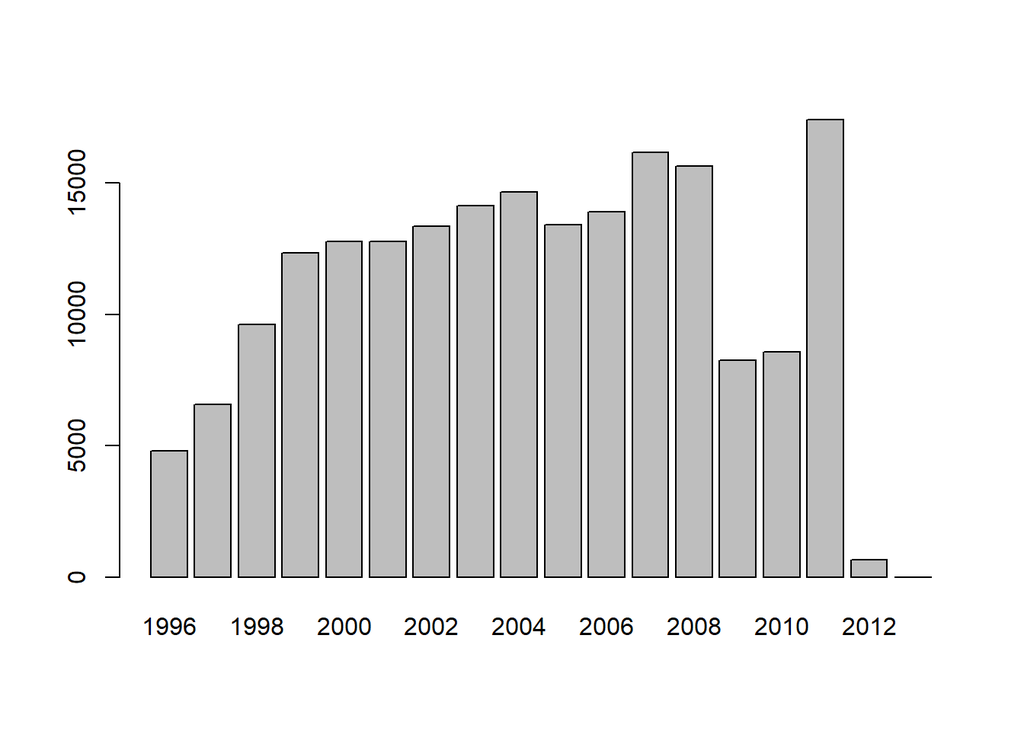

```r
barplot(rok) # ustawienia standardowe
```

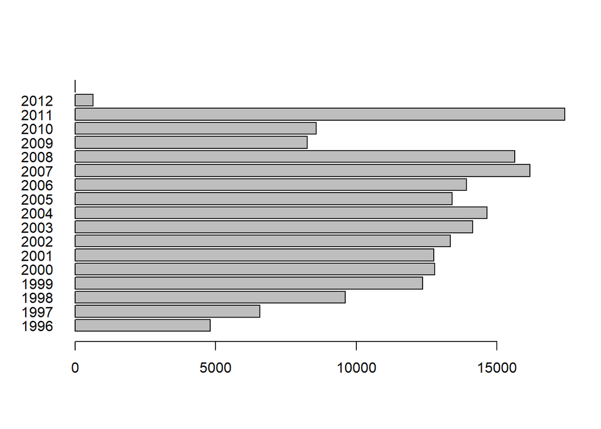

```r
barplot(as.table(rok),
        horiz = T, # poziomo
        las = 1) # # napisy poziomo
```

## 7.5. character or factor

`Character` to oczywiście nazwa typu zmiennej reprezentującej napisy, czyli po prostu tekst `factor` to oczywiście nazwa typu zmiennej reprezentującej grupy.

Z wyglądu, cechy jakościowe (czynniki) przypominają cechy napisowe. Jednak pod spodem, ich reprezentacja jest zupełnie inna. Czynniki nie są pamiętane jako napisy, ale jako para - wektor liczb i słownik, określający, który napis odpowiada, której liczbie.

Na napisach zazwyczaj wykonuje się inne operacje niż na zmiennych jakościowych, może się więc tak zdarzyć, że celowo chcemy jakieś dane odczytać jako napisy. Ale gdy dane są wczytywane z pliku tekstowego w którym są napisy, domyślnie traktowane są jako czynniki.

```r
cat(dane$praca)
```

```
## 1 7 2 1 3 5 4 2 6
```

```r
cat(as.character(dane$praca))
```

```
## AGH ZUS NFZ AGH PK UJ UG NFZ UMK
```

```r
czynnik <- as.factor(dane$kraj) ; str(czynnik)
```

```
##  Factor w/ 3 levels "DE","PL","USA": 1 2 3 3 2 3 1 1 1
```

```r
napisy <- as.character(dane$kraj) ; str(napisy)
```

```
##  chr [1:9] "DE" "PL" "USA" "USA" "PL" "USA" "DE" "DE" "DE"
```

## 7.6. Tablice częstości

Tablice częstości nie są ramkami danych, mimo że wyglądają bardzo podobnie.

A co gdybyśmy chcieli przedstawić zależność pomiędzy dwoma zmiennymi jakościowymi? Można to zrobić używając funkcji `table()` (należy kolejne kolumny(atrybuty) podawać jako kolejne argumenty). Przykładowe wywołanie dla dwóch zmiennych Waluty i Kraju pochodzenia.

```r
table(auta2012$Kraj.pochodzenia, auta2012$Waluta)
```

Jednak wygodniej jest, takie tabele tworzyć używając funkcji `xtabs()`, która jest trochę wygodniejsza w pracy. Pierwszym argumentem tej funkcji jest formuła o składni `~ zmienna_1 + .. + zmienna_n`, t.j. rozpoczynająca się `` ~`` a następnie ze zmiennymi porozdzielanymi znakiem ``+`. Drugim argumentem jest ramka danych, która powinna zawierać zmienne wymienione w formule.

Wynikiem jest tablica kontyngencji o tylu wymiarach, ile zmiennych występuje w formule.

Przykładowo, zestawiając ze sobą kraj pochodzenia oraz walutę w ogłoszeniu, otrzymujemy tablicę częstości o wymiarach 32 wiersze i 8 kolumn. Pierwszy wiersz tej tabeli odpowiada pustej wartości kraju pochodzenia, stąd brak nazwy w pierwszym wierszu.

```r
krajWaluta <- xtabs( ~ Kraj.pochodzenia + Waluta, auta2012)
```

```r
krajWaluta # wyświetlamy
```

Funkcja `prop.table()` liczy procenty (z drugim argumentem =1 liczy procenty w wierszach)

```r
round(prop.table(krajWaluta, 1), 3)
```

```
##                    Waluta
## Kraj.pochodzenia      CHF   CZK   EEK   EUR   GBP   HUF   PLN   USD
##                     0.000 0.057 0.000 0.041 0.000 0.006 0.892 0.004
##   Austria           0.000 0.263 0.000 0.013 0.000 0.000 0.724 0.000
##   Belgia            0.000 0.065 0.000 0.062 0.000 0.000 0.872 0.000
##   Bulgaria          0.000 0.000 0.000 0.000 0.000 0.000 1.000 0.000
##   Chorwacja         0.000 0.000 0.000 0.000 0.000 0.000 1.000 0.000
##   Czechy            0.000 0.990 0.000 0.000 0.000 0.000 0.010 0.000
##   Dania             0.000 0.051 0.000 0.302 0.000 0.000 0.647 0.000
##   Estonia           0.000 0.143 0.000 0.000 0.000 0.000 0.857 0.000
##   Francja           0.000 0.111 0.000 0.004 0.000 0.000 0.885 0.000
##   Grecja            0.000 0.000 0.000 0.000 0.000 0.000 1.000 0.000
##   Hiszpania         0.000 0.072 0.000 0.110 0.000 0.000 0.818 0.000
##   Holandia          0.000 0.022 0.000 0.039 0.000 0.000 0.940 0.000
##   Irlandia          0.000 0.000 0.000 0.037 0.000 0.037 0.926 0.000
##   Islandia          0.000 0.000 0.000 0.000 0.000 0.000 1.000 0.000
##   Kanada            0.000 0.059 0.000 0.010 0.000 0.000 0.922 0.010
##   Litwa             0.000 0.000 0.000 0.000 0.000 0.000 1.000 0.000
##   lotwa             0.000 0.000 0.000 0.000 0.000 0.000 1.000 0.000
##   Luksemburg        0.000 0.040 0.000 0.000 0.000 0.000 0.960 0.000
##   Monako            0.000 0.000 0.000 0.000 0.000 0.000 1.000 0.000
##   Niemcy            0.000 0.084 0.000 0.020 0.000 0.000 0.896 0.000
##   Norwegia          0.000 0.000 0.000 0.000 0.000 0.000 1.000 0.000
##   Polska            0.000 0.000 0.000 0.000 0.000 0.000 1.000 0.000
##   Rosja             0.000 0.077 0.000 0.000 0.000 0.000 0.923 0.000
##   Rumunia           0.000 0.250 0.000 0.000 0.000 0.000 0.750 0.000
##   Slowacja          0.000 0.655 0.000 0.073 0.000 0.000 0.273 0.000
##   Stany Zjednoczone 0.000 0.047 0.000 0.001 0.000 0.000 0.861 0.090
##   Szwajcaria        0.002 0.105 0.000 0.001 0.000 0.000 0.891 0.001
##   Szwecja           0.000 0.045 0.000 0.000 0.000 0.000 0.955 0.000
##   Ukraina           0.000 0.167 0.000 0.000 0.000 0.000 0.833 0.000
##   Wegry             0.000 0.000 0.000 0.000 0.000 0.955 0.045 0.000
##   Wielka Brytania   0.000 0.011 0.000 0.000 0.001 0.000 0.988 0.000
##   Wlochy            0.000 0.401 0.000 0.003 0.000 0.000 0.595 0.000
```

Tablice częstości nie są ramkami danych.

Gdy w grę wchodzą dwie zmienne, to rzeczywiście wyglądają one jak ramki danych - mają wiersze i kolumny. Muszą być jednak czymś innym, ponieważ w sytuacji, gdy tablica kontyngencji dotyczy trzech lub większej liczby zmiennych to wynikowa macierz kontyngencji ma więcej wymiarów niż dwa.

Funkcją `as.data.frame` można przekształcić wielowymiarowe tabele do ramki danych. Otrzyma się w tym przypadku tak zwaną reprezentację rzadką macierzy kontyngencji, w której pierwsze kolumny opisują wszystkie kombinacje czynników zmiennych a ostatnia kolumna opisuje liczebność występowania poszczególnej kombinacji czynników.

```r
xt <- xtabs(~Kraj.pochodzenia+Waluta, auta2012)
xt <- as.data.frame(xt)
xt[xt$Freq > 0, ]
```

## 7.7. Przekształcanie zmiennych ilościowych w jakościowe

Opisując dane ilościowe, często można ułatwić ich zrozumienie, jeżeli zmienne ilościowe podzieli się na przedziały. Takie przedziały są już zmienną jakościową. Zmienną jakościową z ilościowej można stworzyć używając funkcji `cut()`, która za pierwszy argument przyjmuje zmienną ilościową, a jako drugi liczbę przedziałów do zbudowania lub punkty odcięcia dla tych przedziałów.

```r
dane$kateg <- cut(dane$urlop,
                  breaks = c(0,10,max(dane$urlop)))
table(dane$kateg)
```

```
##
##  (0,10] (10,24]
##       5       4
```

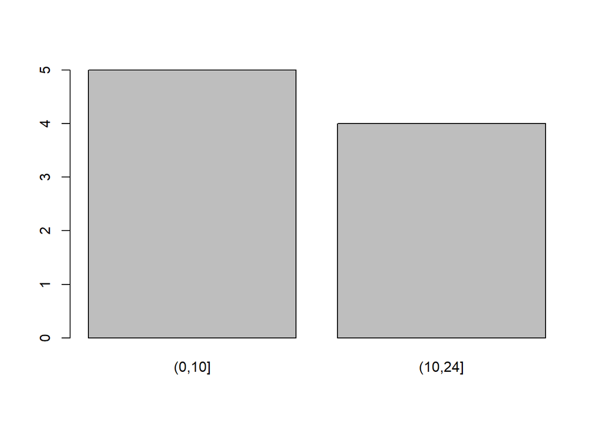

```r
barplot(table(dane$kateg))
```

Teraz wyświetlmy dane, posortowaną względem nowej zmiennej:

```r
sort(table(dane$kateg))
```

```
##
## (10,24]  (0,10]
##       4       5
```

Dwuwymiarową tabelę wykreslimy za pomocą funkcji `mosaicplot()`. Rysuje ona tak zwany wykres mozaikowy przedstawiający jednocześnie wiele zależności.

```r
levels(auta2012$Skrzynia.biegow)
```

```
## [1] ""             "automatyczna" "manualna"
```

```r
levels(auta2012$Rodzaj.paliwa)
```

```
## [1] "benzyna"                "benzyna+LPG"
## [3] "etanol"                 "hybryda"
## [5] "naped elektryczny"      "olej napedowy (diesel)"
```

```r
tab <- xtabs(~Rodzaj.paliwa + Skrzynia.biegow, auta2012)
```

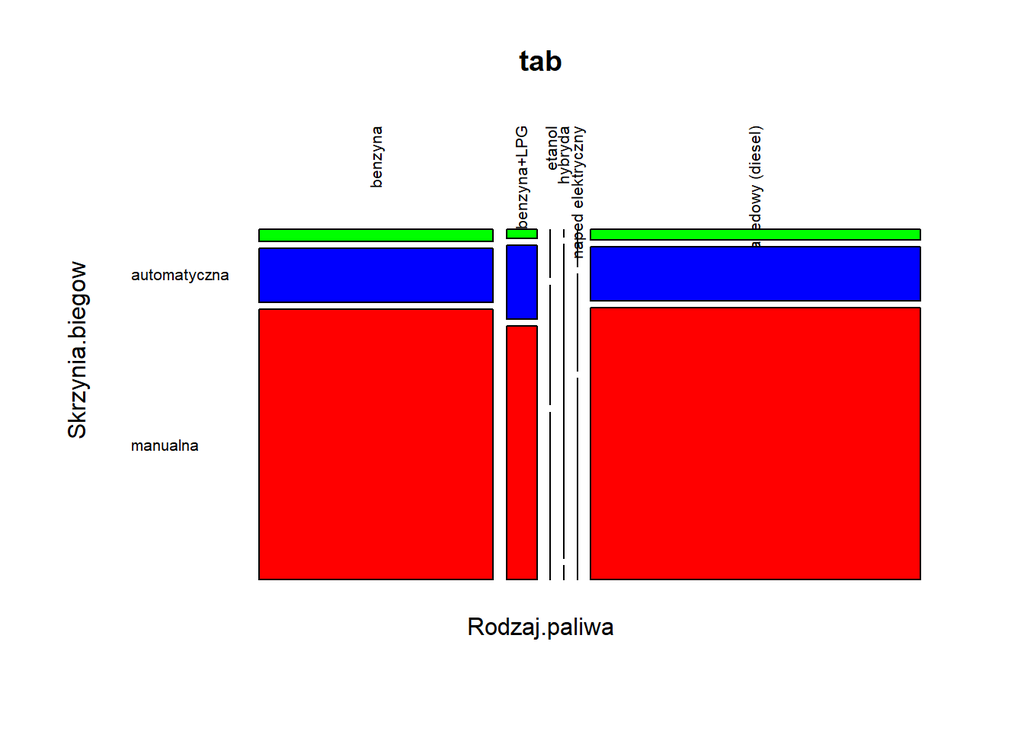

```r
mosaicplot(tab, las=2, col=c("green", "blue", "red"))
```

Zróbmy coś innego. Wczytamy dane mydata i wygenerujemy wykres częstości przedziałów prędkości wiatru.

```r
install.packages("openair")
library(openair)
View(mydata)
```

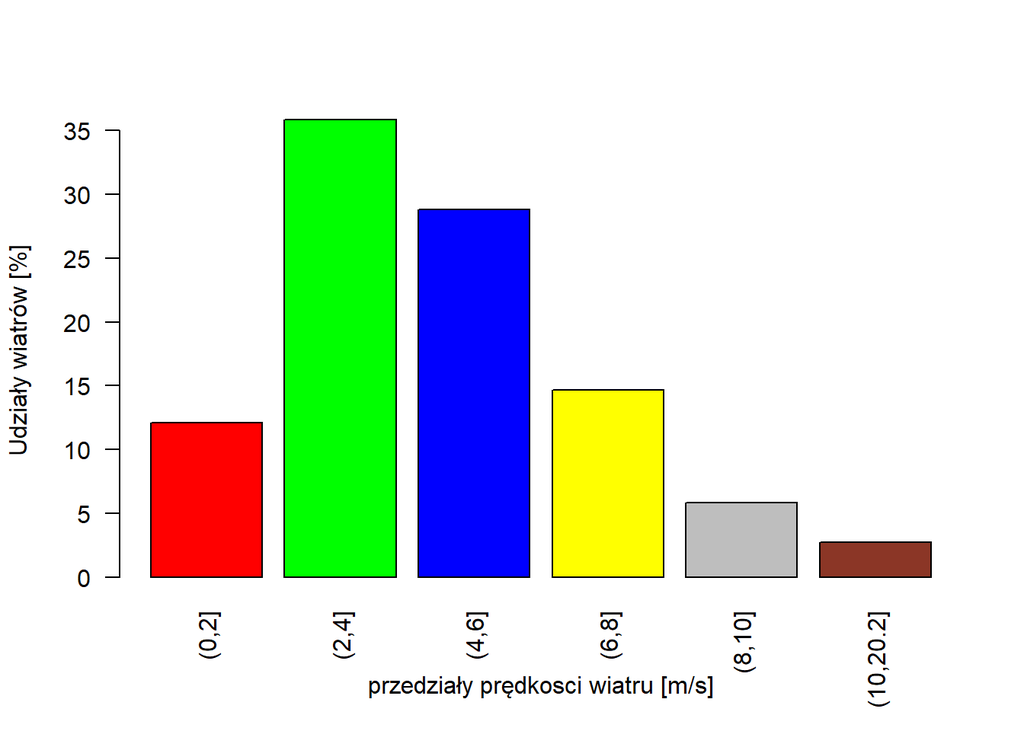

```r
mydata$p.ws <- cut(mydata$ws, c(0, 2,4,6,8, 10, max(mydata$ws, na.rm = T)))
a <- round(prop.table(table(mydata$p.ws)),4)*100
barplot(a,  las = 2, col = c("red", "green","blue", "yellow", "grey", "tomato4"),
        xlab = "przedziały prędkosci wiatru [m/s]", ylab =  "Udziały wiatrów [%]")
```

```r
colors()
```

```
##   [1] "white"                "aliceblue"            "antiquewhite"
##   [4] "antiquewhite1"        "antiquewhite2"        "antiquewhite3"
##   [7] "antiquewhite4"        "aquamarine"           "aquamarine1"
##  [10] "aquamarine2"          "aquamarine3"          "aquamarine4"
##  [13] "azure"                "azure1"               "azure2"
##  [16] "azure3"               "azure4"               "beige"
##  [19] "bisque"               "bisque1"              "bisque2"
##  [22] "bisque3"              "bisque4"              "black"
##  [25] "blanchedalmond"       "blue"                 "blue1"
##  [28] "blue2"                "blue3"                "blue4"
##  [31] "blueviolet"           "brown"                "brown1"
##  [34] "brown2"               "brown3"               "brown4"
##  [37] "burlywood"            "burlywood1"           "burlywood2"
##  [40] "burlywood3"           "burlywood4"           "cadetblue"
##  [43] "cadetblue1"           "cadetblue2"           "cadetblue3"
```

[output cut: 204 more lines]

## 7.8. Kolejność i nazwy czynników

Domyślna kolejność czynników, to kolejność leksykograficzna. Tworząc wykresy, zazwyczaj wartości prezentowane są zgodnie z kolejnością opisaną przez atrybut levels.

```r
levels(auta2012$Rodzaj.paliwa)
```

```
## [1] "benzyna"                "benzyna+LPG"
## [3] "etanol"                 "hybryda"
## [5] "naped elektryczny"      "olej napedowy (diesel)"
```

Stworzymy wykres roku produkcji względem rodzaju spalanego paliwa

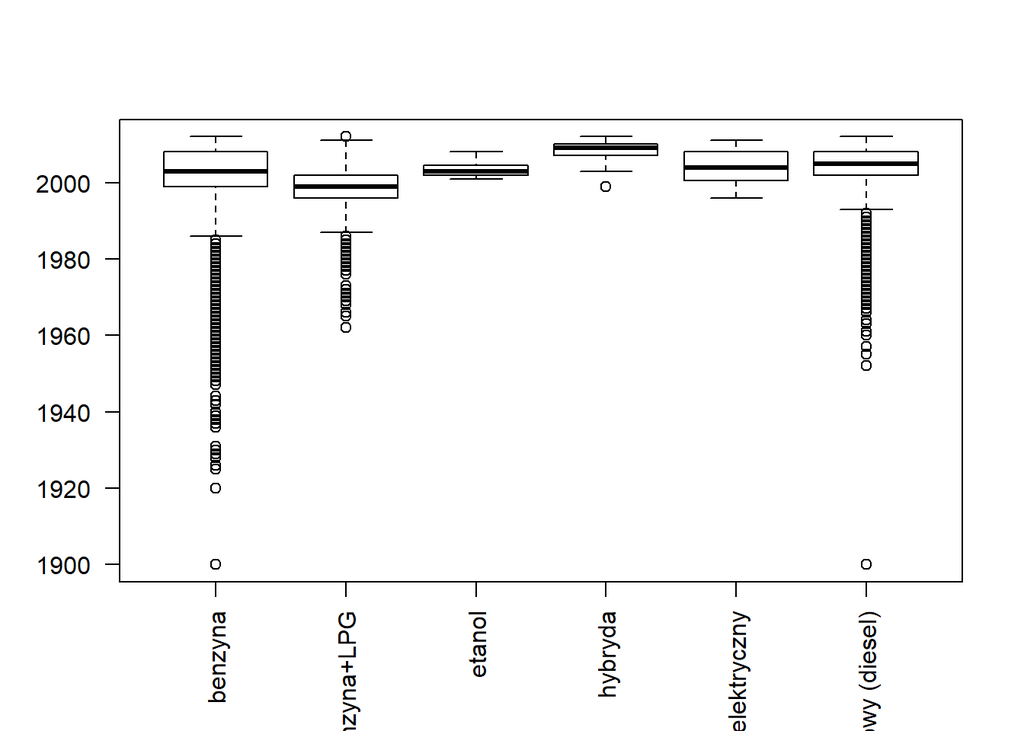

```r
boxplot(Rok.produkcji ~ Rodzaj.paliwa, auta2012, las=2)
```

Domyślną kolejność można zmienić. Jednym ze sposobów określania kolejności czynników jest argument levels w funkcji `factor()`. Czynniki będą mieć kolejność zgodną z tam wskazaną. Nazwy czynników można też dowolnie zmieniać. Najprościej można to zrobić używając funkcji `levels()` tak jak na poniższym przykładzie.Nazwy czynników można też dowolnie zmieniać. Najprościej można to zrobić używając funkcji `levels()` tak jak na poniższym przykładzie.

```r
levels(auta2012$Skrzynia.biegow)
```

```
## [1] ""             "automatyczna" "manualna"
```

```r
auta2012$Skrzynia.biegow <- factor(auta2012$Skrzynia.biegow,
                                   levels=c("manualna","automatyczna", ""))
levels(auta2012$Skrzynia.biegow)
```

```
## [1] "manualna"     "automatyczna" ""
```

Jeżeli chcemy ,,posortować’’ poziomy zgodnie z pewną cechą ilościową, to wygodne będzie użycie funkcji `reorder()`. Jako argumenty pobiera ona wektor ze zmienną czynnikową, wektor z dowolną zmienną i funkcję. Dla każdej grupy określonej przez zmienną czynnikową, dla wartości wskazanych przez drugi argument wyznaczana jest wartość funkcji - trzeciego argumentu. Następnie czynniki są porządkowane zgodnie z kolejnością wyników trzeciej funkcji.

W przykładzie poniżej, rodzaje paliwa są porządkowane zgodnie ze średnim rokiem produkcji aut o określonym rodzaju paliwa. Tak jak się można spodziewać, bardziej ,,nowoczesne’’ paliwa są w autach młodszych.

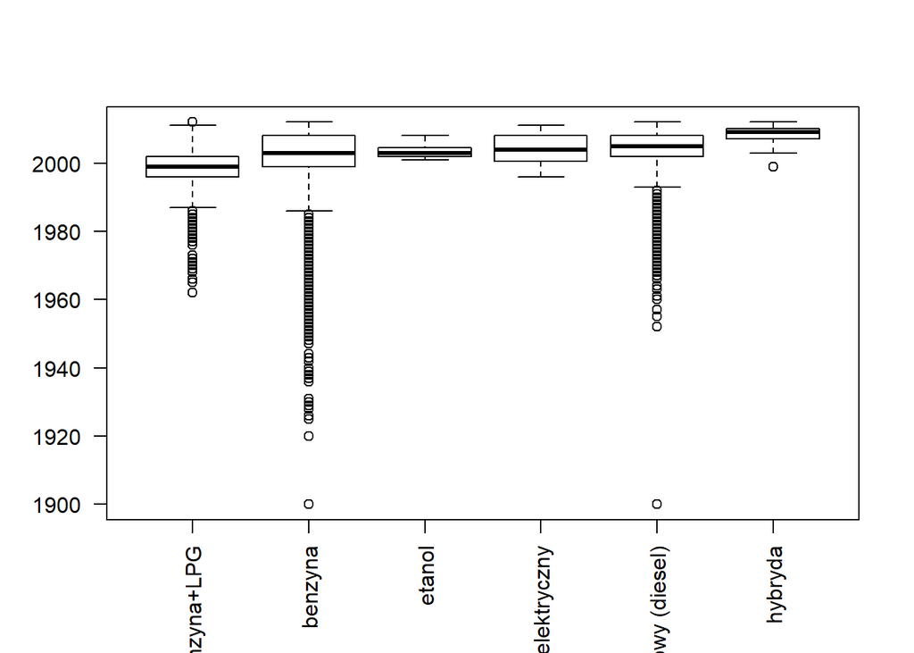

```r
auta2012$sort <- reorder(auta2012$Rodzaj.paliwa, # jakościowa
                         auta2012$Rok.produkcji, # ilościowa
                         mean)
boxplot(Rok.produkcji ~ sort, auta2012, las=2)
```

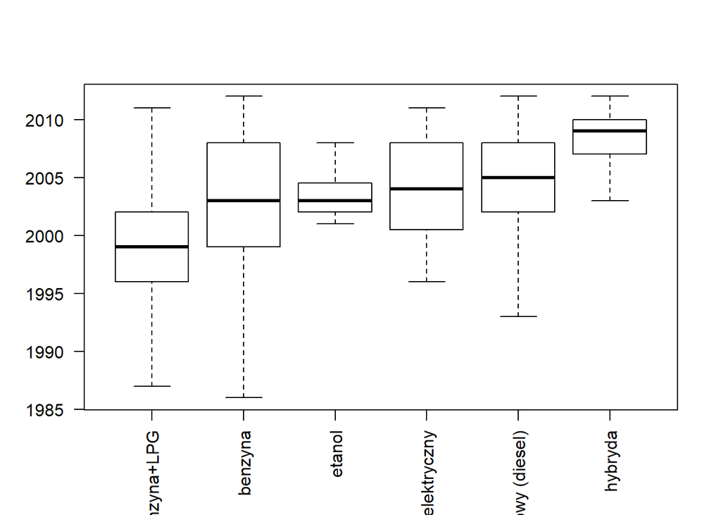

```r
boxplot(Rok.produkcji ~ sort, auta2012,
        las=2, outline = F) # bez odstających obs.
```

##### Ćwiczenie 1

###### Odp.

Ile zmiennych jakosciowych jest w w zbiorze danych `mydata` z pakietu `openair`?

```r
str(mydata)
```

```
## Classes 'tbl_df', 'tbl' and 'data.frame':    65533 obs. of  11 variables:
##  $ date: POSIXct, format: "1998-01-01 00:00:00" "1998-01-01 01:00:00" ...
##  $ ws  : num  0.6 2.16 2.76 2.16 2.4 3 3 3 3.36 3.96 ...
##  $ wd  : int  280 230 190 170 180 190 140 170 170 170 ...
##  $ nox : int  285 NA NA 493 468 264 171 195 137 113 ...
##  $ no2 : int  39 NA NA 52 78 42 38 51 42 39 ...
##  $ o3  : int  1 NA 3 3 2 0 0 0 1 2 ...
##  $ pm10: int  29 37 34 35 34 16 11 12 12 12 ...
##  $ so2 : num  4.72 NA 6.83 7.66 8.07 ...
##  $ co  : num  3.37 NA 9.6 10.22 8.91 ...
##  $ pm25: int  NA NA NA NA NA NA NA NA NA NA ...
##  $ p.ws: Factor w/ 6 levels "(0,2]","(2,4]",..: 1 2 2 2 2 2 2 2 2 2 ...
```

Cecha Marka opisuje markę samochodu. Sprawdź, która marka jest najpopularniejsza?

```r
head(sort(table(auta2012$Marka), decreasing = T),1)
```

```
## Volkswagen
##      22826
```

```r
tail(sort(table(auta2012$Marka)),1)
```

```
## Volkswagen
##      22826
```

Cecha Rodzaj.paliwa opisuje rodzaj paliwa wykorzystywanego przez auto. Czy jest to benzyna, olej, gaz?

```r
levels(auta2012$Rodzaj.paliwa)
```

```
## [1] "benzyna"                "benzyna+LPG"
## [3] "etanol"                 "hybryda"
## [5] "naped elektryczny"      "olej napedowy (diesel)"
```

Sprawdź jaki procent samochodów jest napędzana na benzynę?

```r
prop.table(table(auta2012$Rodzaj.paliwa))*100 -> a
sort(a, decreasing = T)
```

```
##
## olej napedowy (diesel)                benzyna            benzyna+LPG
##            55.37422568            39.35125866             5.14638587
##                hybryda      naped elektryczny                 etanol
##             0.08814944             0.02649300             0.01348735
```

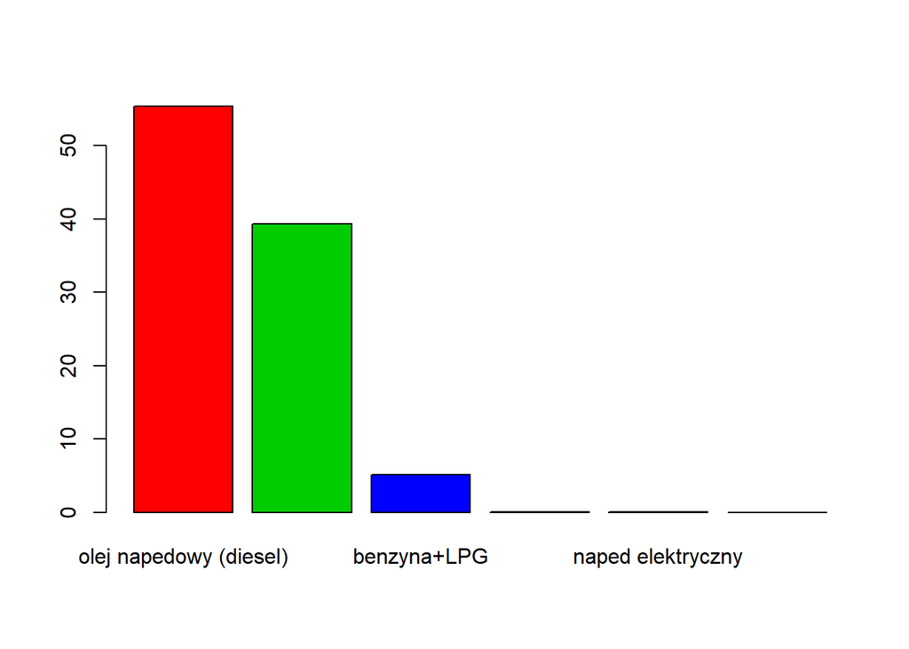

```r
barplot(sort(a, decreasing = T),
        col =c(2:7)) #  numery kolorów
```

```r
p1 <- c(1900,1995,2000,2005,2010,2012)
p2 <- c(0, 1000, 10000, 100000, 1000000, 10000000)

auta2012$Rok.prod.prz <- cut(auta2012$Rok.produkcji, breaks = p1)
auta2012$Prze.km.prz <- cut(auta2012$Przebieg.w.km, breaks = p2)
```

Wyznacz tabelę liczebności dla tych dwóch nowych zmiennych.Przedstaw tę tabelę graficznie.

```r
table(auta2012$Rok.prod.prz,
      auta2012$Prze.km.prz) -> a ;a
```

```
##
##               (0,1e+03] (1e+03,1e+04] (1e+04,1e+05] (1e+05,1e+06]
##   (1900,1995]       196            39           681          6757
##   (1995,2000]       532            32          1996         34052
##   (2000,2005]       555            44          8839         50578
##   (2005,2010]       614          2174         30273         24480
##   (2010,2012]      2104          2459          1559             3
##
##               (1e+06,1e+07]
##   (1900,1995]            16
##   (1995,2000]            20
##   (2000,2005]            25
##   (2005,2010]             7
##   (2010,2012]             0
```

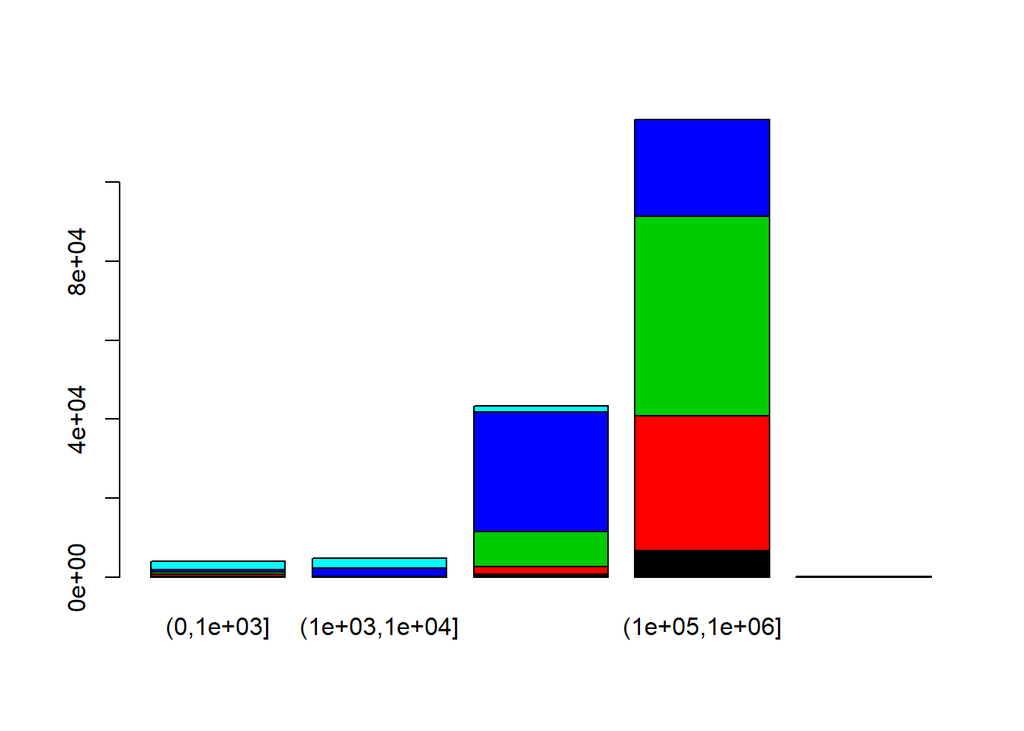

```r
barplot(a, col = c(1:20))
```

Biecek, Przemysław. 2008. *Przewodnik po pakiecie R*. Oficyna wydawnicza GIS.